# 4. Lenguajes de programación.

## Lenguaje de programación

Podemos definir un **lenguaje de programación** como un idioma creado de forma artificial, formado por un conjunto de símbolos y normas que se aplican sobre un alfabeto para obtener un código, que el hardware del ordenador pueda entender y ejecutar.

En este sentido, es muy importante tener clara la función principal de los lenguajes de programación como instrumentos para que el ordenador realice las tareas que necesitamos.

O más formalmente:

> Un **sistema formal de comunicación** diseñado para que los seres humanos puedan **escribir instrucciones que un ordenador pueda interpretar y ejecutar**.

## Generaciones de lenguajes

### 1. Lenguaje máquina (1ª generación)

- Es el más primitivo.
- Conjunto de instrucciones en **código binario (0 y 1)** directamente ejecutadas por la CPU.
- **Muy difícil de programar y mantener**, dependiente del hardware.
- Ejemplo:

  `10110000 01100001`

### 2. Lenguajes ensamblador (2ª generación)

- Introducen **mnemónicos** y símbolos más fáciles de recordar que el binario.
- Cada instrucción corresponde casi directamente a una instrucción de máquina.
- Se necesita un **ensamblador** para traducirlo a código máquina.
- Ejemplo:

  `MOV AL, 61h`

### 3. Lenguajes de alto nivel (3ª generación)

- Mayor abstracción, independientes del hardware.
- Usan **estructuras cercanas al lenguaje humano** (inglés) y permiten centrarse en el algoritmo más que en el hardware.
- Requieren **compiladores o intérpretes**.
- Ejemplos: **Fortran, COBOL, C, Pascal, BASIC, Java, Python**.

### 4. Lenguajes de cuarta generación (4GL)

- Más orientados a la **productividad** y al **qué** se quiere hacer en lugar del **cómo**.
- Se usan en entornos de **bases de datos, gestión empresarial y generación automática de código**.
- Ejemplos: **SQL, MATLAB, ABAP, Informix 4GL, Oracle Forms**.

### 5. Lenguajes de quinta generación (5GL)

- Basados en **paradigmas declarativos y lógicos**.
- Se enfocan en la **resolución de problemas mediante restricciones** más que en instrucciones secuenciales.
- Se asocian con la **inteligencia artificial** y la programación declarativa.
- Ejemplos: **Prolog, Mercury, OPS5**.

### 6. Lenguajes modernos multiparadigma

- Integran características de varios estilos: **imperativo, orientado a objetos, funcional, reactivo**.
- Buscan **legibilidad, portabilidad y escalabilidad**.
- Ejemplos: **Java, C#, Kotlin, Scala, Rust, Go, Swift, TypeScript**.

**Resumen evolutivo:**

**1GL** → Máquina (binario).

**2GL** → Ensamblador (mnemónicos).

**3GL** → Alto nivel estructurado y OOP (C, Java, Python…).

**4GL** → Lenguajes declarativos y de productividad (SQL, MATLAB…).

**5GL** → Basados en restricciones, lógica e IA (Prolog).

**Multiparadigma modernos** → Fusionan paradigmas (imperativos, funcionales, orientados a objetos, lógicos) para mayor flexibilidad (Rust, Kotlin, TypeScript…).

## Características principales

### Alfabeto

- **Alfabeto**: conjunto finito de todos los símbolos básicos que se utilizan para construir programas con un lenguaje. Estos símbolos pueden ser letras, números, o caracteres especiales y definen los bloques de construcción de cualquier código.

#### Alfabeto mínimo en pseudocódigo (PSeInt)

```
Σ = { Letras: a…z, A…Z
    Dígitos: 0…9
    Símbolos: ← , + - * / < > = ( ) ;
    Espacio y salto de línea }
```

Con este alfabeto ya podrías escribir:

`suma ← 3 + 5 Si suma > 7 Entonces Escribir "Mayor que 7" FinSi`

#### Alfabeto simplificado para un lenguaje estilo C/Java

```
Σ = { Letras: a…z, A…Z
    Dígitos: 0…9
    Símbolos: + - * / = < > ! & | ; , . ( ) { } [ ]
    Espacios: ␣ (espacio), \n (salto de línea), \t (tabulación) }
```

Con este alfabeto, podemos construir *tokens* del lenguaje como:

- Palabras clave: `if`, `while`, `return`
- Identificadores: `contador`, `sumaTotal`
- Operadores: `+`, `!=`, `&&`
- Números: `123`, `3.14`

### Sintaxis

- **Sintaxis**: reglas que definen cómo se escriben las instrucciones (su estructura) y formalmente expresadas mediante otros lenguajes como **bnf**.

#### Asignación en un lenguaje estilo C/Java mediante bnf

```
<asignacion> ::= <identificador> "=" <expresion> ";"
<identificador> ::= <letra> { <letra> | <digito> }
<expresion> ::= <identificador> | <numero> | <expresion> <op> <expresion>
<op> ::= "+" | "-" | "*" | "/"
<numero> ::= <digito> { <digito> }
<letra> ::= "a" | … | "z" | "A" | … | "Z"
<digito> ::= "0" | … | "9"
```

Con estas reglas podemos generar frases válidas como:

```java
x = 5;
total = x + 3;
```

#### Estructura de selección en un lenguaje estilo C/Java mediante bnf

```
<if> ::= "if" "(" <condicion> ")" <bloque> [ "else" <bloque> ]

<condicion> ::= <expresion> <op_rel> <expresion>
<op_rel> ::= "==" | "!=" | "<" | ">" | "<=" | ">="

<bloque> ::= "{" { <sentencia> } "}"
```

```java
if (x > 0) {
    y = y + 1;
} else {
    y = 0;
}
```

Puedes ampliar y jugar a definir tu propia sintaxis en sitios como **BNF Playground** [bnfplayground](https://bnfplayground.pauliankline.com)

### Semántica

- **Semántica**: significado de las instrucciones escritas. Se refiere al **significado** de una instrucción, no a cómo se escribe (eso es la sintaxis).

```java
x = 5 + 3;
/*
Semántica de suma y asignación: el compilador interpreta que debe calcular la suma de `5 + 3`, asignar el valor `8` a la variable `x`, y reservar un espacio  en memoria para guardar ese valor
*/

if (x > 10) {
    System.out.println("Mayor que 10");
}
/*
Semántica de condición: la máquina debe evaluar la condición `x > 10`.

- Si la condición es verdadera, ejecuta la instrucción dentro de las llaves (imprimir en pantalla).

- Si es falsa, no hace nada.
*/
```

- **Primitivas**: conjunto de elementos más pequeños con un significado semántico que un programador puede utilizar. Ej: tipo de dato simple (como `number`, `boolean`) , una acción elemental (como la asignación o la lectura de datos) que no se puede descomponer en componentes más pequeños.
- **Abstracción**: proceso de ocultar los detalles complejos de implementación y mostrar sólo lo esencial de una entidad o sistema, centrándose en qué hace, en lugar de cómo lo hace. Esto simplifica el diseño, reduce la complejidad, mejora escalabilidad y permite a los desarrolladores interactuar con componentes sin conocer su funcionamiento interno (**funciones, objetos, módulos**, etc.).

Un lenguaje de programación va a permitir, además, expresar **algoritmos** y manipular **datos** de forma que un programa pueda:

- Realizar cálculos.
- Procesar información.
- Interactuar con hardware y software.
- Resolver problemas concretos.

## Lenguajes de programación estructurada

La programación estructurada se define como una técnica para escribir lenguajes de programación que permite sólo el uso de tres tipos de sentencias o estructuras de control:

- Sentencias secuenciales.
- Sentencias selectivas (condicionales).
- Sentencias repetitivas (iteraciones o bucles).

Esta técnica favorece los **bloques** con ámbito bien definido. Promueve la **descomposición** del problema en **subprogramas** (procedimientos y funciones). Y su objetivo es escribir software **legible, verificable y mantenible**, evitando el *código espagueti*.

Ideas fundacionales de la programación estructurada (qué es y por qué importa)

- **Modelo de control reducido**: cualquier algoritmo puede expresarse con **secuencia**, **selección** (`if/else`) e **iteración** (`while/for`).
- **Entrada única / salida única** de cada bloque (single-entry/single-exit) para que el flujo sea predecible.
- **Bloques con ámbito**: variables locales, ocultación de detalles y menor acoplamiento.
- **Descomposición top-down** (refinamiento progresivo): partir del problema general e ir refinándolo en pasos hasta llegar a implementaciones simples.
- **Especificación formal**: **precondiciones**, **poscondiciones** e **invariantes** permiten razonar (y probar) la corrección.
- **Evitar `goto`** y saltos incontrolados que rompen la trazabilidad del flujo.

> Resultado: programas más fáciles de **entender**, **probar** y **evolucionar**.

### Las 3 estructuras de control:

#### Secuencia

- **Secuencia**: instrucciones ejecutadas en orden.

```
Algoritmo BloqueSecuencia
    Definir a, b, suma Como Entero

    a <- 5
    b <- 3
    suma <- a + b

    Escribir "La suma es: ", suma
FinAlgoritmo
```

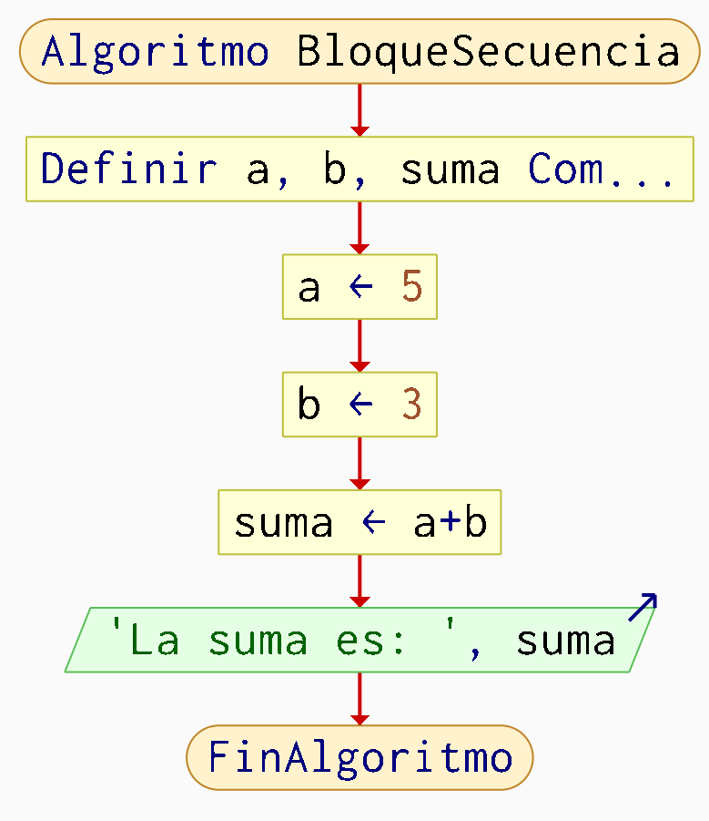

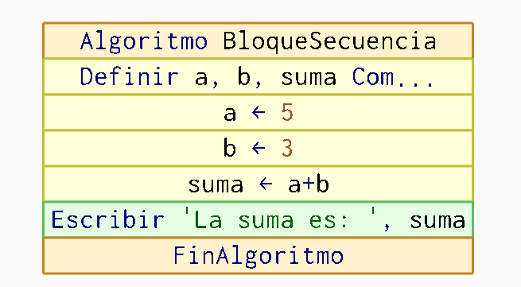

```java
public class BloqueSecuencia {
    public static void main(String[] args) {
        // Bloque de secuencia: instrucciones que se ejecutan en orden
        int a = 5;                  // 1. Declaración e inicialización
        int b = 3;                  // 2. Declaración e inicialización
        int suma = a + b;           // 3. Operación
        System.out.println(suma);   // 4. Salida por pantalla
    }
}
```

```javascript
// Bloque de secuencia en JavaScript
let a = 5;              // 1. Declaración e inicialización
let b = 3;              // 2. Declaración e inicialización
let suma = a + b;       // 3. Operación
console.log(suma);      // 4. Salida por consola
```

#### Selección o alternativa

- **Selección**: bifurcación controlada (`if/else`, `switch`).

##### if/else

```
Algoritmo EjemploIfElse
    Definir numero Como Entero

    numero <- 7

    Si numero % 2 = 0 Entonces
        Escribir "El número es par"
    Sino
        Escribir "El número es impar"
    FinSi
FinAlgoritmo
```

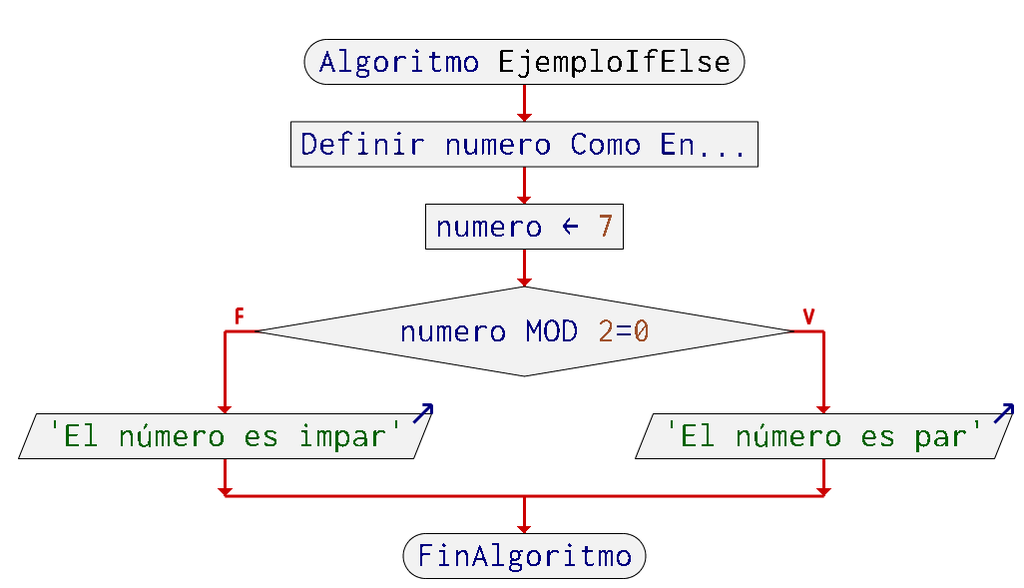

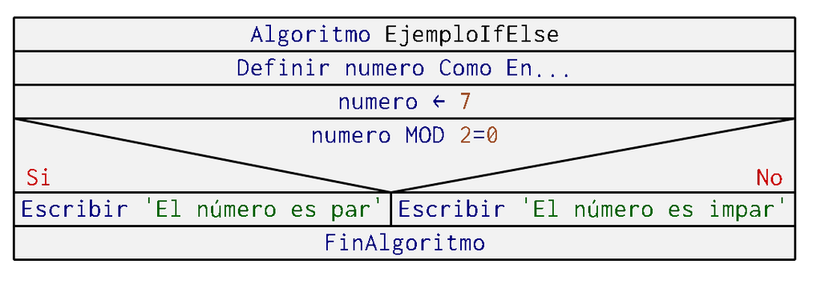

```java
public class EjemploIfElse {
    public static void main(String[] args) {
        int numero = 7;

        if (numero % 2 == 0) {
            System.out.println("El número es par");
        } else {
            System.out.println("El número es impar");
        }
    }
}
```

```javascript
let numero = 7;

if (numero % 2 === 0) {
    console.log("El número es par");
} else {
    console.log("El número es impar");
}
```

##### switch

```
Algoritmo EjemploSwitch
    Definir dia Como Entero
    Definir nombreDia Como Cadena

    dia <- 3

    Segun dia Hacer
        1:
            nombreDia <- "Lunes"
        2:
            nombreDia <- "Martes"
        3:
            nombreDia <- "Miércoles"
        4:
            nombreDia <- "Jueves"
        5:
            nombreDia <- "Viernes"
        6:
            nombreDia <- "Sábado"
        7:
            nombreDia <- "Domingo"
        De Otro Modo:
            nombreDia <- "Día inválido"
    FinSegun

    Escribir "El día es: ", nombreDia
FinAlgoritmo
```

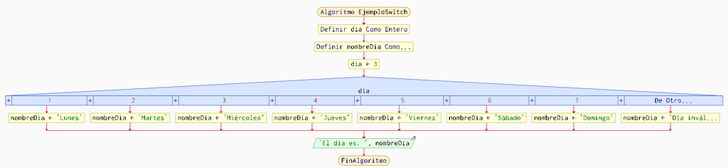

Ampliar

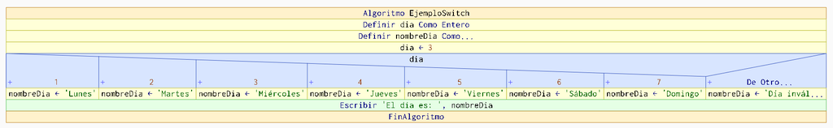

Ampliar

```java
public class EjemploSwitch {
    public static void main(String[] args) {
        int dia = 3;
        String nombreDia;

        switch (dia) {
            case 1:
                nombreDia = "Lunes";
                break;
            case 2:
                nombreDia = "Martes";
                break;
            case 3:
                nombreDia = "Miércoles";
                break;
            case 4:
                nombreDia = "Jueves";
                break;
            case 5:
                nombreDia = "Viernes";
                break;
            case 6:
                nombreDia = "Sábado";
                break;
            case 7:
                nombreDia = "Domingo";
                break;
            default:
                nombreDia = "Día inválido";
        }

        System.out.println("El día es: " + nombreDia);
    }
}
```

Variantes de java moderno se **switch** con **lambdas** y **yield**:

```java
int dia = 6;

String tipo = switch (dia) {
    case 1, 2, 3, 4, 5 -> "Día laboral";
    case 6, 7 -> "Fin de semana";
    default -> "Valor inválido";
};

System.out.println("Tipo: " + tipo);
```

```java
int dia = 2;
//Desde java 14+
String mensaje = switch (dia) {
    case 1, 2, 3 -> {
        String prefijo = "Principio de semana: ";
        yield prefijo + (dia == 1 ? "Lunes" : dia == 2 ? "Martes" : "Miércoles");
    }
    case 4 -> "Jueves";
    case 5 -> "Viernes";
    case 6, 7 -> "Fin de semana";
    default -> "Día inválido";
};

System.out.println(mensaje);
```

js sólo tiene la forma clásica de **case/break** hasta que se apruebe mejora de js del pattern-matching:

```javascript
let dia = 3;
let nombreDia;

switch (dia) {
    case 1:
        nombreDia = "Lunes";
        break;
    case 2:
        nombreDia = "Martes";
        break;
    case 3:
        nombreDia = "Miércoles";
        break;
    case 4:
        nombreDia = "Jueves";
        break;
    case 5:
        nombreDia = "Viernes";
        break;
    case 6:
        nombreDia = "Sábado";
        break;
    case 7:
        nombreDia = "Domingo";
        break;
    default:
        nombreDia = "Día inválido";
}

console.log("El día es: " + nombreDia);
```

#### Iteración o repetitiva

- **Iteración**: repetición con condición clara (`while`, `for`, `do/while`).

  *Regla práctica*: cada bucle debe responder “¿qué cambia para que termine?” (variable de control) y “¿qué se mantiene cierto?” (invariante).

##### while/mientras:

```
Algoritmo EjemploMientras
    Definir i Como Entero
    i <- 1

    Mientras i <= 5 Hacer
        Escribir "Valor de i: ", i
        i <- i + 1
    FinMientras
FinAlgoritmo
```

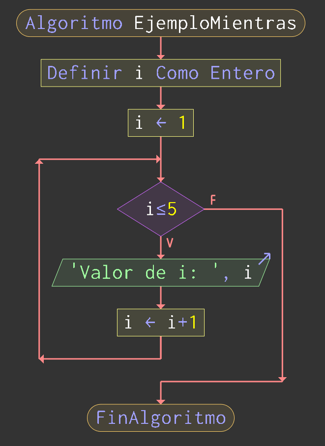

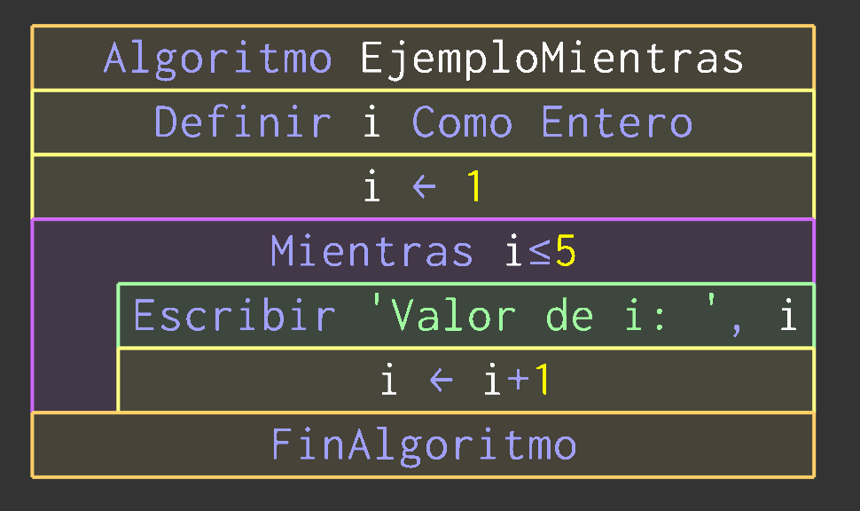

```java
public class EjemploMientras {
    public static void main(String[] args) {
        int i = 1;
        while (i <= 5) {
            System.out.println("Valor de i: " + i);
            i++;
        }
    }
}
```

```javascript
let i = 1;
while (i <= 5) {
    console.log("Valor de i:", i);
    i++;
}
```

##### repeat/repetir:

```
Algoritmo EjemploRepetir
    Definir i Como Entero
    i <- 1

    Repetir
        Escribir "Valor de i: ", i
        i <- i + 1
    Hasta Que i > 5
FinAlgoritmo
```

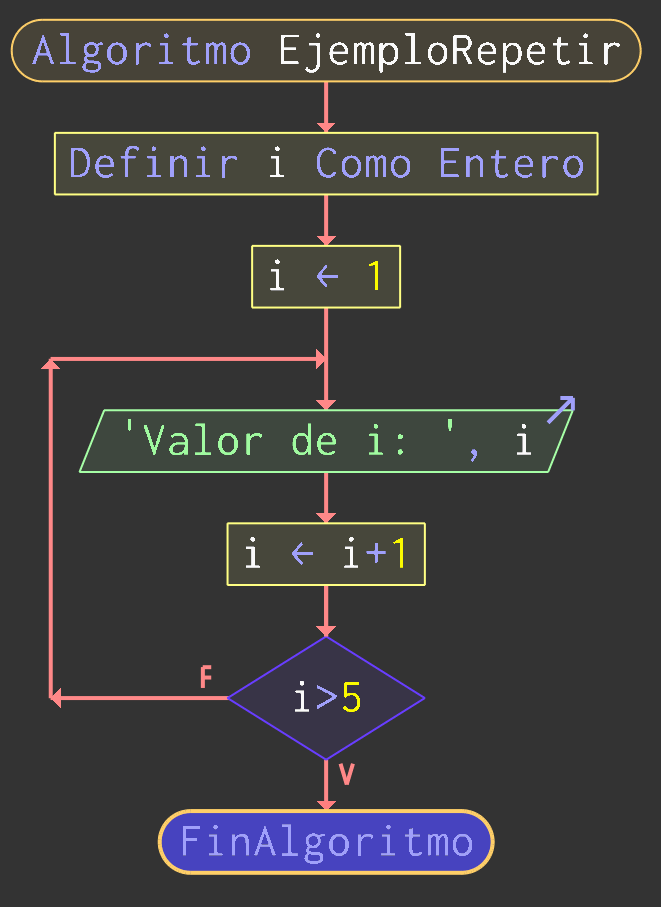

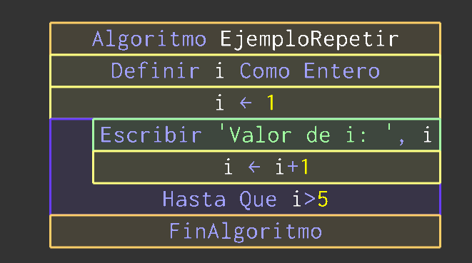

```java
public class EjemploRepetir {
    public static void main(String[] args) {
        int i = 1;
        do {
            System.out.println("Valor de i: " + i);
            i++;
        } while (i <= 5);
    }
}
```

```javascript
let j = 1;
do {
    console.log("Valor de j:", j);
    j++;
} while (j <= 5);
```

##### para/for:

```
Algoritmo EjemploPara
    Definir i Como Entero

    Para i <- 1 Hasta 5 Con Paso 1 Hacer
        Escribir "Valor de i: ", i
    FinPara
FinAlgoritmo
```

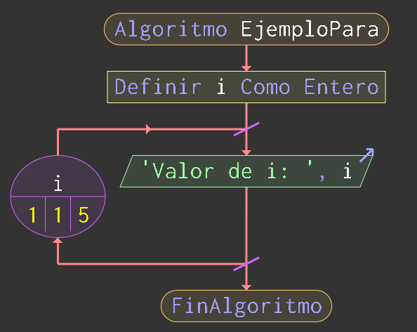

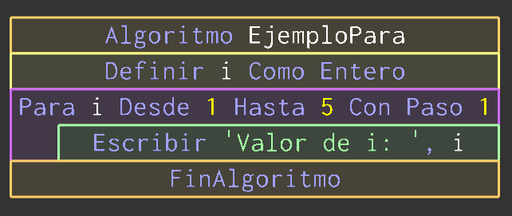

```java
//desde java 11+
class EjemploPara {
    void main() {
        for (int i = 1; i <= 5; i++) {
            System.out.println("Valor de i: " + i);
        }
    }
}
```

```java
//desde java 21+
void main() {
    for (int i = 1; i <= 5; i++) {
        System.out.println("Valor de i: " + i);
    }
}
```

```javascript
for (let i = 1; i <= 5; i++) {
    console.log("Valor de i:", i);
}
```

### Bloques y ámbito

- Delimita variables a las zonas donde se usan.
- Minimiza el estado compartido (global) para reducir efectos colaterales.

### Subprogramas/funciones

- Cada función/procedimiento con **una única responsabilidad**.
- Firma y contrato claros (pre/post).
- Tamaño reducido (regla informal: función que “cabe en pantalla” y se lee sin desplazarse).

### Refinamiento progresivo (top-down)

Empezar con pseudo-código de alto nivel y refinar pasos “obvios” en subrutinas hasta llegar a operaciones primitivas. Se parte del problema en su forma más general y abstracta y, **paso a paso**, se va dividiendo en **subproblemas más concretos**, hasta llegar a operaciones simples que puedan codificarse directamente en un lenguaje de programación.

```
Nivel alto:
```

```yaml
        Programa calcular promedio:
           Leer los datos
           Calcular promedio
           Mostrar resultado
```

```
Primer refinamiento:
```

```yaml
        Leer los datos:
           Pedir cantidad de números
           Leer cada número y almacenarlo

        Calcular promedio:
           Sumar todos los números
           Dividir suma entre la cantidad

        Mostrar resultado:
           Imprimir promedio
```

```
2º refinamiento psuedo-código:
```

```
        Pedir n
        suma = 0
        para i desde 1 hasta n hacer
             leer número
             suma = suma + número
        fin para
        promedio = suma / n
        escribir promedio
```

### Corrección por construcción

- **Precondición**: qué debe cumplirse antes de invocar.
- **Poscondición**: qué garantiza al terminar.
- **Invariante** de bucle: condición que permanece cierta en cada iteración y facilita probar terminación/corrección.
6. **Disciplina de salidas**
- Tradicionalmente: una salida por función.
- **En la práctica moderna**: **guard clauses** (salidas tempranas) pueden **mejorar** la claridad (p. ej. validar y salir si hay error) si no generan flujos enmarañados.

### Beneficios y límites

#### Beneficios

- Reduce la **complejidad accidental**.
- Facilita **pruebas unitarias** y **depuración**.
- Mejora **mantenibilidad** y **reusabilidad** (abstracción adecuada).

#### Límites / matices

- Puede aparecer **anidación excesiva** si se aplica sin guard clauses.
- No sustituye prácticas como **diseño modular**, **abstracción de datos** u **OOP**; más bien **convive** con ellas (OOP bien hecha es *estructurada + modular + abstracción de datos*).

### Métricas útiles (para mantener la estructura bajo control)

- **Complejidad ciclomatica (McCabe)**: número de caminos independientes.
  - Orientativa: **≤ 10** por función es manejable; si sube, **extrae** funciones o simplifica condiciones.
- **Profundidad de anidación**: mantenerla baja (≤ 3–4).
- **Longitud de función** y **número de parámetros**: señales de diseño a vigilar.

### Técnicas y artefactos

- **Pseudocódigo estructurado** en vez de diagrama de flujo cargado.
- **Diagramas Nassi-Shneiderman** (estructuras “caja-dentro-caja” para secuencia/selección/bucle).
- **Diseño por contrato** (pre/post/invariantes).
- **Pruebas**: caja blanca (rutas) + caja negra (contratos).